# This task is given durring initial process of iternship given by internshala

## Define the Deep learning model with sequential model

```python
batch_size = 256
num_classes = 10
epochs = 50

#input image dimensions
img_rows, img_cols = 28, 28

model = Sequential()
model.add(Conv2D(32, kernel_size=(3, 3),
                 activation='relu',
                 kernel_initializer='he_normal',
                 input_shape=input_shape))
model.add(MaxPooling2D((2, 2)))
model.add(BatchNormalization())
model.add(Dropout(0.25))
model.add(Conv2D(64, (3, 3), activation='relu',activity_regularizer=regularizers.l2(1e-5)))
model.add(MaxPooling2D(pool_size=(2, 2)))
model.add(BatchNormalization())
model.add(Dropout(0.25))
model.add(Conv2D(128, (3, 3), activation='relu',activity_regularizer=regularizers.l2(1e-5)))
model.add(BatchNormalization())
model.add(Dropout(0.4))
model.add(Flatten())
model.add(Dense(128, activation='relu',activity_regularizer=regularizers.l2(1e-5)))
model.add(BatchNormalization())
model.add(Dropout(0.3))
model.add(Dense(num_classes, activation='softmax'))

model.compile(loss=keras.losses.categorical_crossentropy,
              optimizer=keras.optimizers.Adam(),
              metrics=['accuracy'])
model.summary()
```

```
Model: "sequential"
_________________________________________________________________
Layer (type)                 Output Shape              Param #
=================================================================
conv2d (Conv2D)              (None, 26, 26, 32)        320
_________________________________________________________________
max_pooling2d (MaxPooling2D) (None, 13, 13, 32)        0
_________________________________________________________________
batch_normalization (BatchNo (None, 13, 13, 32)        128
_________________________________________________________________
dropout (Dropout)            (None, 13, 13, 32)        0
_________________________________________________________________
conv2d_1 (Conv2D)            (None, 11, 11, 64)        18496
_________________________________________________________________
max_pooling2d_1 (MaxPooling2 (None, 5, 5, 64)          0
_________________________________________________________________
batch_normalization_1 (Batch (None, 5, 5, 64)          256
_________________________________________________________________
dropout_1 (Dropout)          (None, 5, 5, 64)          0
_________________________________________________________________
conv2d_2 (Conv2D)            (None, 3, 3, 128)         73856
_________________________________________________________________
batch_normalization_2 (Batch (None, 3, 3, 128)         512
_________________________________________________________________
dropout_2 (Dropout)          (None, 3, 3, 128)         0
_________________________________________________________________
flatten (Flatten)            (None, 1152)              0
_________________________________________________________________
dense (Dense)                (None, 128)               147584
_________________________________________________________________
batch_normalization_3 (Batch (None, 128)               512
_________________________________________________________________
dropout_3 (Dropout)          (None, 128)               0
_________________________________________________________________
dense_1 (Dense)              (None, 10)                1290
=================================================================
Total params: 242,954
Trainable params: 242,250
Non-trainable params: 704
_________________________________________________________________
```

# Train it with adam optimizer

```python
early = EarlyStopping(monitor='val_loss', mode='min', verbose=1, patience=5)
callback = LearningRateScheduler(scheduler)

output = model.fit(X_train, y_train,
          batch_size=batch_size,
          epochs=50,
          verbose=1,
          validation_data=(X_val, y_val),callbacks=[callback,early])
```

```
Epoch 00032: early stopping
```

# Plot accuracy and loss plot

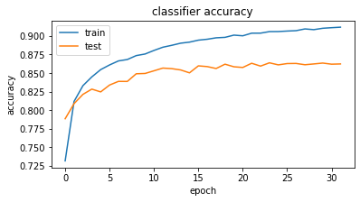

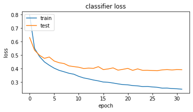

```python
plt.figure(figsize=(6,3))
#history of accuracy
plt.plot(output.history['accuracy'])
plt.plot(output.history['val_accuracy'])
plt.title('classifier accuracy')
plt.ylabel('accuracy')
plt.xlabel('epoch')
plt.legend(['train', 'test'], loc='upper left')
plt.show()
# summarize history for loss
plt.figure(figsize=(6,3))
plt.plot(output.history['loss'])
plt.plot(output.history['val_loss'])
plt.title('classifier loss')
plt.ylabel('loss')
plt.xlabel('epoch')
plt.legend(['train', 'test'], loc='upper left')
plt.show()
```

# Test accuracy and loss values

```python
score = model.evaluate(X_test, y_test, verbose=0)
print('Test loss:', score[0])
print('Test accuracy:', score[1])
```

```
Test loss: 0.2690594494342804
Test accuracy: 0.9074166417121887
```

# Now perfrom model analysis how my model perfrom on blurry and notblurry images

Take 100 image from test set, extract edges from it, then test it with model, then make them blurry and extract edges then test it with our model and print loss,accuracyv values for both cases

## A not blurry image

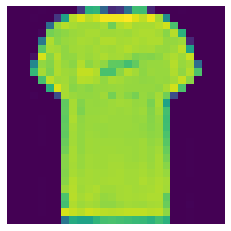

```python
plt.imshow(not_blurry_x[10].reshape(28,28))
plt.axis("off");
```

# Extract edges from not blurry images

```python
for i in range(not_blurry_x.shape[0]):
    img = preprocessing(not_blurry_x[i].reshape(28,28))
    img = img.reshape(28,28,1)
    not_blurry_x[i] = img
```

# Plot edges of a not blurry

[figure not shown]

```python
plt.imshow(not_blurry_x[10].reshape(28,28))
plt.axis("off");
```

## Blurry version of top not blurry image

```
(28, 28, 1)
```

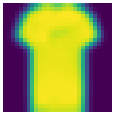

```python
img = blurry_x[10]
print(img.shape)
img = img.astype(np.float32)
img = cv2.GaussianBlur(img,(5,5),1)
plt.imshow(img.reshape(28,28))
plt.axis("off");
```

# Plot blurry edge detected version of that image

```python
for i in range(blurry_x.shape[0]):
    img = blurry_x[i]
    img = img.astype('float32')
    img = np.reshape(img,(28,28))
    img = cv2.GaussianBlur(img,(5,5),1)
    img = preprocessing(img.reshape(28,28))
    img = img.reshape(28,28,1)
    blurry_x[i] = img
```

# Plot edges of a blurry

[figure not shown]

```python
plt.imshow(blurry_x[10].reshape(28,28))
plt.axis("off");
```

## Test the model with not_blurry images,print it loss and accuracy

```python
score = model.evaluate(not_blurry_x/255., test_y, verbose=0)
print('Test loss:', score[0])
print('Test accuracy:', score[1])
```

```
Test loss: 0.3100737929344177
Test accuracy: 0.9100000262260437
```

## Test the model with blurry images,print it loss and accuracy

```python
score = model.evaluate(blurry_x/255., test_y, verbose=0)
print('Test loss:', score[0])
print('Test accuracy:', score[1])
```

```
Test loss: 0.34435921907424927
Test accuracy: 0.8899999856948853
```

# Save the model as h5 file

```python
#save model
model.save(r"/content/drive/My Drive/fashion mnist/model.h5")
```

# Load the model and test it whether it perfrom well or not

```python
# load model
model = load_model("/content/drive/My Drive/fashion mnist/model.h5")
```

```python
# summarize model.
model.summary()
```

```
Model: "sequential"
_________________________________________________________________
Layer (type)                 Output Shape              Param #
=================================================================
conv2d (Conv2D)              (None, 26, 26, 32)        320
_________________________________________________________________
max_pooling2d (MaxPooling2D) (None, 13, 13, 32)        0
_________________________________________________________________
batch_normalization (BatchNo (None, 13, 13, 32)        128
_________________________________________________________________
dropout (Dropout)            (None, 13, 13, 32)        0
_________________________________________________________________
conv2d_1 (Conv2D)            (None, 11, 11, 64)        18496
_________________________________________________________________
max_pooling2d_1 (MaxPooling2 (None, 5, 5, 64)          0
_________________________________________________________________
batch_normalization_1 (Batch (None, 5, 5, 64)          256
_________________________________________________________________
dropout_1 (Dropout)          (None, 5, 5, 64)          0
_________________________________________________________________
conv2d_2 (Conv2D)            (None, 3, 3, 128)         73856
_________________________________________________________________
batch_normalization_2 (Batch (None, 3, 3, 128)         512
_________________________________________________________________
dropout_2 (Dropout)          (None, 3, 3, 128)         0
_________________________________________________________________
flatten (Flatten)            (None, 1152)              0
_________________________________________________________________
dense (Dense)                (None, 128)               147584
_________________________________________________________________
batch_normalization_3 (Batch (None, 128)               512
_________________________________________________________________
dropout_3 (Dropout)          (None, 128)               0
_________________________________________________________________
dense_1 (Dense)              (None, 10)                1290
=================================================================
Total params: 242,954
Trainable params: 242,250
Non-trainable params: 704
_________________________________________________________________
```

```python
score = model.evaluate(blurry_x/255., test_y, verbose=0)
print('Test loss:', score[0])
print('Test accuracy:', score[1])
```

```
Test loss: 0.34435921907424927
Test accuracy: 0.8899999856948853
```